# BIOST 561: basics of tidyverse and ggplot

Lecture 3

# Announcements

- This lecture is the “last” lecture about “how to code” in R
  - From next lecture onwards, we’re moving onto the “software engineering” side of coding
- HW2 is due April 28, 7pm
- You will “submit” HW2 the same way you did HW1 (just pushing all the relevant files onto your GitHub)

# Quick notes about HW1

- I will be providing feedback on your homework this weekend via GitHub “issues”
  - “Complete”: (But I might still give some feedback)
  - “Redo”: (I will give you some guidelines on what needs to be improved)
- Please make sure there is no `.gitignore` file in your `vignettes` folder

# Quick notes about HW1

- Please show your code in your knitted document. That is, do **not** set `echo=FALSE` in the code chunk. I want to see the code in the HTML document.
- In your R code chunk in Markdown, you can set `fig.width` and/or `out.width` to make your knitted plot to be bigger.
  - See http://zevross.com/blog/2017/06/19/tips-and-tricks-for-working-with-images-and-figures-in-r-markdown-documents/

# Tidyverse

# Workflow of most data analyses

# tibbles

Data frames are great! Except for

- printing them
- working with both characters and factors
- manipulating multiple columns

`tibble`s are the data frame alternative of the tidyverse

# tibbles

A tibble, or tbl_df, is a modern reimagining of the data.frame, keeping what time has proven to be effective, and throwing out what is not. Tibbles are data.frames that are lazy and surly: they do less (i.e. they don’t change variable names or types, and don’t do partial matching) and complain more (e.g. when a variable does not exist). This forces you to confront problems earlier, typically leading to cleaner, more expressive code. Tibbles also have an enhanced print method() which makes them easier to use with large datasets containing complex objects.

- Hadley Wickham, Chief Scientist at RStudio

# tibbles

From https://rdrr.io/cran/medicaldata/man/covid_testing.html:

```r
library(medicaldata)
covid_testing
```

```
## # A tibble: 15,524 × 17
##    subject_id fake_first_name fake_last_name gender pan_day test_id clinic_name
##         <dbl> <chr>           <chr>          <chr>    <dbl> <chr>   <chr>
##  1       1412 jhezane         westerling     female       4 covid   inpatient w…
##  2        533 penny           targaryen      female       7 covid   clinical lab
##  3       9134 grunt           rivers         male         7 covid   clinical lab
##  4       8518 melisandre      swyft          female       8 covid   clinical lab
##  5       8967 rolley          karstark       male         8 covid   emergency d…
##  6      11048 megga           karstark       female       8 covid   oncology da…
##  7        663 ithoke          targaryen      male         9 covid   clinical lab
##  8       2158 ravella         frey           female       9 covid   emergency d…
##  9       3794 styr            tyrell         male         9 covid   clinical lab
## 10       4706 wynafryd        seaworth       male         9 covid   clinical lab
## # ℹ 15,514 more rows
## # ℹ 10 more variables: result <chr>, demo_group <chr>, age <dbl>,
## #   drive_thru_ind <dbl>, ct_result <dbl>, orderset <dbl>, payor_group <chr>,
## #   patient_class <chr>, col_rec_tat <dbl>, rec_ver_tat <dbl>
```

# How do we read code?

Translate the following code into words:

```r
length(unique(covid_testing$clinic_name))
```

```
## [1] 88
```

# Intuitive coding

```r
covid_testing %>% pull(clinic_name) %>% unique %>% length
```

```
## [1] 88
```

`%>%` is the “pipe operator”

- `f(x)` is the same as `x %>% f`
- “Take `x` and apply the function `f`”

# Data analysis with tidyverse

Let’s look at how we might answer the following data analysis questions:

- Which patient was the oldest?
- How many days into the pandemic did positive cases appear?
- What was the precentage of positives among age?

# Using `filter()`

Which patient(s) was the oldest?

```r
covid_testing %>%
  filter(age == max(age))
```

```
## # A tibble: 1 × 17
##   subject_id fake_first_name fake_last_name gender pan_day test_id clinic_name
##        <dbl> <chr>           <chr>          <chr>    <dbl> <chr>   <chr>
## 1       3049 sansa           westerling     female     105 covid   line clinica…
## # ℹ 10 more variables: result <chr>, demo_group <chr>, age <dbl>,
## #   drive_thru_ind <dbl>, ct_result <dbl>, orderset <dbl>, payor_group <chr>,
## #   patient_class <chr>, col_rec_tat <dbl>, rec_ver_tat <dbl>
```

`filter()` finds *rows* that meet criteria

# Using `filter()`

How many days into the pandemic did positive cases appear?

```r
covid_testing %>%
  filter(result == "positive") %>%
  pull(pan_day) %>%
  quantile
```

```
##   0%  25%  50%  75% 100%
##   10   39   64   87  107
```

# Using `summarize()`

What was the precentage of positives among males above the age of 20?

```r
covid_testing %>%
  filter(gender == "male" &
           age >= 20) %>%
  summarize(length(which(result == "positive"))/n())
```

```
## # A tibble: 1 × 1
##   `length(which(result == "positive"))/n()`
##                                       <dbl>
## 1                                    0.0854
```

`summarize()`/`summarize()` finds *summaries* of multiple rows

# Using `summarize()`

Even better…

```r
covid_testing %>%
  filter(gender == "male" &
           age >= 20) %>%
  summarize(positive_rate = length(which(result == "positive"))/n())
```

```
## # A tibble: 1 × 1
##   positive_rate
##           <dbl>
## 1        0.0854
```

```r
# also equivalent, using `count()`
filter_tib <- covid_testing %>%
  filter(gender == "male" & age >= 20) %>% count(result)
filter_tib %>% filter(result == "positive") %>%
  summarize(percentage = n / sum(filter_tib$n))
```

```
## # A tibble: 1 × 1
##   percentage
##        <dbl>
## 1     0.0854
```

The latter strategy uses the `count()` function, but due to how piping works, you need to split the process into two functions.

# Using `group_by()`

What was the precentage of positives among age?

```r
covid_testing %>%
  filter(age == 0) %>%
  summarize(positive_rate = length(which(result == "positive"))/n(),
            n = n())
```

```
## # A tibble: 1 × 2
##   positive_rate     n
##           <dbl> <int>
## 1        0.0456   263
```

```r
covid_testing %>%
  filter(age == 0.1) %>%
  summarize(positive_rate = length(which(result == "positive"))/n(),
            n = n())
```

```
## # A tibble: 1 × 2
##   positive_rate     n
##           <dbl> <int>
## 1        0.0413   218
```

```r
# etc...
```

This approach is not scalable… Can we do it all at once?

# Using `group_by()`

```r
positive_rate_tib <- covid_testing %>%
  group_by(age) %>%
  summarize(positive_rate = length(which(result == "positive"))/n(),
            n = n())

positive_rate_tib
```

```
## # A tibble: 111 × 3
##      age positive_rate     n
##    <dbl>         <dbl> <int>
##  1   0          0.0456   263
##  2   0.1        0.0413   218
##  3   0.2        0.0249   241
##  4   0.3        0.0476   189
##  5   0.4        0.0373   161
##  6   0.5        0.0580   207
##  7   0.6        0.0355   197
##  8   0.7        0.0548   219
##  9   0.8        0.0374   214
## 10   0.9        0.0452   199
## # ℹ 101 more rows
```

`group_by()` allows you to perform any operation “by group”

# Writing beautiful code

The alternative:

```r
unique_ages <- sort(unique(covid_testing$age))
positive_rate <- sapply(unique_ages, function(age){
  idx <- which(covid_testing$age == age)
  n <- length(idx)
  positive_n <- length(which(covid_testing$result[idx] == "positive"))
  positive_n/n
})

positive_rate_tib$positive_rate[1:5]
```

```
## [1] 0.04562738 0.04128440 0.02489627 0.04761905 0.03726708
```

```r
positive_rate[1:5]
```

```
## [1] 0.04562738 0.04128440 0.02489627 0.04761905 0.03726708
```

# dplyr

*dplyr is a grammar of data manipulation, providing a consistent set of verbs that help you solve the most common data manipulation challenges:*

- `filter()` picks cases based on their values.
- `summarize()` reduces multiple values down to a single summary.
- `mutate()` adds new variables that are functions of existing variables
- `select()` picks variables based on their names.
- `arrange()` changes the ordering of the rows

These all combine naturally with `group_by()` which allows you to perform any operation “by group”.

# Short example about `mutate()`

In contrast to `summarize()` (which summarizes a lot of rows with one number), `mutate()` adds a new column based on the some function/calculation using other variables.

Here, we simply use `mutate()` to combine the fake first and last name.

```r
covid_testing %>%
  mutate(full_name = paste(fake_first_name, fake_last_name)) %>%
  select(full_name)
```

```
## # A tibble: 15,524 × 1
##    full_name
##    <chr>
##  1 jhezane westerling
##  2 penny targaryen
##  3 grunt rivers
##  4 melisandre swyft
##  5 rolley karstark
##  6 megga karstark
##  7 ithoke targaryen
##  8 ravella frey
##  9 styr tyrell
## 10 wynafryd seaworth
## # ℹ 15,514 more rows
```

# The pipe

`%>%` is included in every `tidyverse` package

- `x %>% f` is equivalent to `f(x)`
- `x %>% f()` is equivalent to `f(x)`
- `x %>% f(y)` is equivalent to `f(x, y)`
- `x %>% f(y, .)` is equivalent to `f(y, x)`

# Advanced piping

There are actually multiple different types of pipes (not just `%>%`)

You need to load `magrittr` to use the following:

- `covid_testing %$% name` is `covid_testing[, "name"]` *as a vector*
- `x %<>% f` is equivalent to `x <- f(x)`

# Watch out!

```r
covid_testing
  %>% filter(result == "positive") %>%
  pull(pan_day)
```

```
## Error in parse(text = input): <text>:2:3: unexpected SPECIAL
## 1: covid_testing
## 2:   %>%
##      ^
```

# tidyverse

Depending on when and how you learned `R`, transitioning to `tidyverse` may be frustrating and take time.

- e.g., Unlearning bad habits gets harder over time
- Graduate school is a great time for learning new things and creating new habits!

Starting to program using tidyverse will make your code more readable, debug-able, robust, and efficient.

# Some context for HW2: Graphs

For your homework, you’ll need to need know a bit about graphs. A simple way to learn about this is through the `igraph` package. (You won’t need this package for your homework. This is for demonstration purposes.)

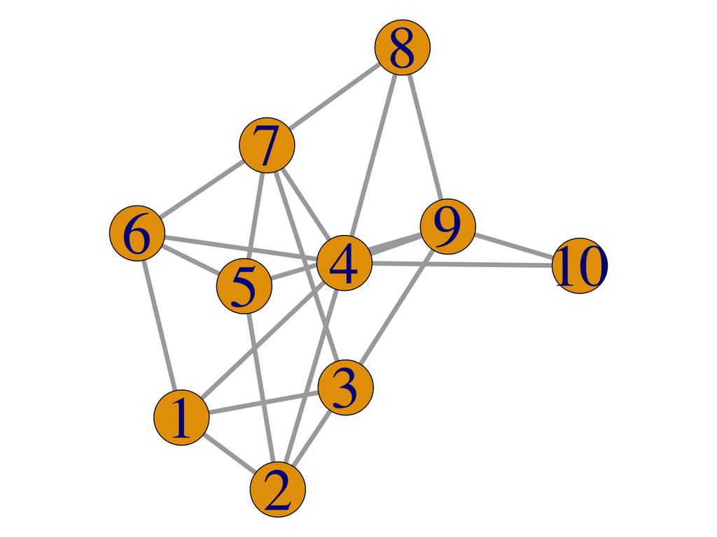

```r
library(igraph)
set.seed(10)
g <- igraph::sample_gnp(10, 0.5)
plot(g)
```

```r
adj_mat <- igraph::as_adjacency_matrix(g)
adj_mat
```

```
## 10 x 10 sparse Matrix of class "dgCMatrix"
##
##  [1,] . 1 1 1 . 1 . . . .
##  [2,] 1 . 1 1 1 . . . . .
##  [3,] 1 1 . . . . 1 . 1 .
##  [4,] 1 1 . . . 1 1 1 1 1
##  [5,] . 1 . . . 1 1 . 1 .
##  [6,] 1 . . 1 1 . 1 . . .
##  [7,] . . 1 1 1 1 . 1 . .
##  [8,] . . . 1 . . 1 . 1 .
##  [9,] . . 1 1 1 . . 1 . 1
## [10,] . . . 1 . . . . 1 .
```

- The `adj_mat` (i.e., the adjacency matrix) represents the same graph as the plot.
- The labeling of the nodes is arbitrary though. This is the same “graph”

```r
adj_mat[c(6:10,1:5), c(6:10,1:5)]
```

```
## 10 x 10 sparse Matrix of class "dgCMatrix"
##
##  [1,] . 1 . . . 1 . . 1 1
##  [2,] 1 . 1 . . . . 1 1 1
##  [3,] . 1 . 1 . . . . 1 .
##  [4,] . . 1 . 1 . . 1 1 1
##  [5,] . . . 1 . . . . 1 .
##  [6,] 1 . . . . . 1 1 1 .
##  [7,] . . . . . 1 . 1 1 1
##  [8,] . 1 . 1 . 1 1 . . .
##  [9,] 1 1 1 1 1 1 1 . . .
## [10,] 1 1 . 1 . . 1 . . .
```

- We care about the relations between nodes, **not** which nodes are literally assigned “1”, “2”, “3”, …
- A simple way to visualize an adjacency matrix is using the `image()` function

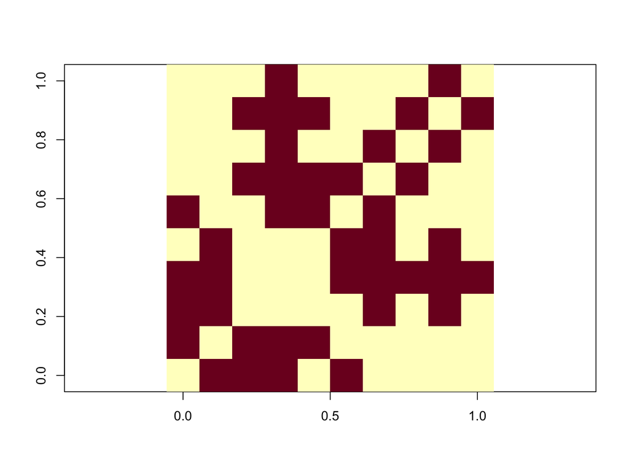

```r
image(as.matrix(adj_mat), asp = TRUE)
```

- In HW2, you’ll make a nicer-looking plot via ggplot.

# 5 minute break

# Group exercise (feel free to work with your table-mates)

Suppose I’m given this matrix that encodes a graph:

```r
set.seed(10)
adj_mat <- matrix(stats::rbinom(n = 100,
                                size = 1,
                                prob = 0.25),
                  nrow = 10,
                  ncol = 10)
adj_mat <- adj_mat + t(adj_mat) #Symmeterize
adj_mat[adj_mat > 0] <- 1
diag(adj_mat) <- 0 #Remove self-edges
adj_mat
```

```
##       [,1] [,2] [,3] [,4] [,5] [,6] [,7] [,8] [,9] [,10]
##  [1,]    0    0    1    0    0    0    0    0    1     0
##  [2,]    0    0    0    0    0    1    0    0    0     1
##  [3,]    1    0    0    0    0    0    1    0    1     0
##  [4,]    0    0    0    0    0    0    1    1    0     0
##  [5,]    0    0    0    0    0    0    1    0    0     1
##  [6,]    0    1    0    0    0    0    1    0    0     1
##  [7,]    0    0    1    1    1    1    0    0    1     0
##  [8,]    0    0    0    1    0    0    0    0    0     0
##  [9,]    1    0    1    0    0    0    1    0    0     0
## [10,]    0    1    0    0    1    1    0    0    0     0
```

How could you (using code):

- Determine the node(s) with the largest number of edges?
- Determine if the graph is connected (i.e., there is a way to go from any node to any other node)?

(By the way, this graph looks like this):

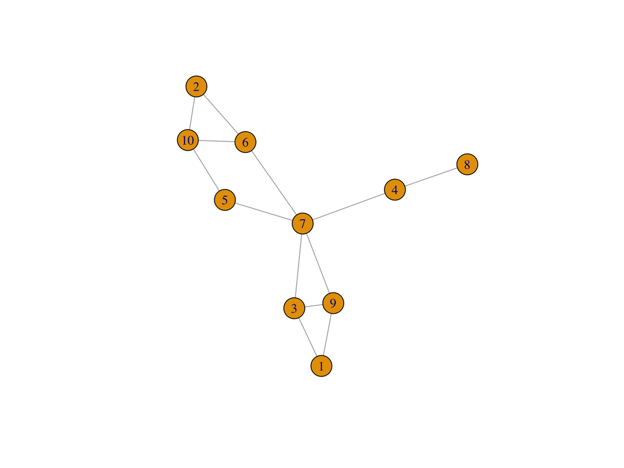

```r
g <- igraph::graph_from_adjacency_matrix(adj_mat,
                                         mode = "undirected")
plot(g)
```

# Graphics

# Graphical communication in practice

Graphical communication is critical for both *exploring* and *explaining* data.

There are lots of different ways to make graphics in `R`.

Today, we’re going to talk about `ggplot`: a toolkit for creating beautiful, data-rich statistical graphics in `R`!

# ggplot

- `ggplot` is a function available in the `ggplot2` package.
- Graphics are built in layers: a plot is initialised, *then* data is then drawn, *then* annotations are added.
- Annotations include
  - scales
  - labels
  - legends
  - coordinate systems

# What’s in a name? **Grammar of Graphics** - Leland Wilkinson

All plots can be broken down into core components

1. **data**
2. **geometries**: type of geometric objects to represent data, e.g., points, lines
3. **aesthetics**: visual characteristics of geometric objects to represent data, e.g., position, size
4. **scales**: how each aesthetics is converted into values on the graph, e.g., color scales
5. **stats**: statistical transformations to summarize data, e.g., counts, means, regression lines
6. **facets**: split data and view as multiple graphs
7. **coordinate system**: 2D space the data are projected onto, e.g., Cartesian coordinates

# What’s in a name? **Grammar of Graphics** - Leland Wilkinson

All plots can be broken down into core components

1. **data**
2. **geometries**: type of geometric objects to represent data, e.g., points, lines
3. **aesthetics**: visual characteristics of geometric objects to represent data, e.g., position, size
4. **scales**: how each aesthetics is converted into values on the graph, e.g., color scales
5. **stats**: statistical transformations to summarize data, e.g., counts, means, regression lines
6. **facets**: split data and view as multiple graphs
7. **coordinate system**: 2D space the data are projected onto, e.g., Cartesian coordinates

[Hadley Wickham expanded upon this](https://vita.had.co.nz/papers/layered-grammar.pdf) with **ggplot2**

1. `data`
2. `geom`
3. `aes`: mappings of columns to geometric objects
4. `scale`: one scale for each `aes` variable
5. `stat`:
6. `facet`:
7. `coord`:
8. `labs`: labels/guides for each variable and othe parts of the plot, e.g., title, subtitle, caption
9. `theme`: customization of plot layout

# The dataset we’ll be working with

```r
library(rigr)
library(tidyverse)
fev %>% as_tibble
```

```
## # A tibble: 654 × 7
##    seqnbr subjid   age   fev height sex    smoke
##     <int>  <int> <int> <dbl>  <dbl> <chr>  <chr>
##  1      1    301     9  1.71   57   female no
##  2      2    451     8  1.72   67.5 female no
##  3      3    501     7  1.72   54.5 female no
##  4      4    642     9  1.56   53   male   no
##  5      5    901     9  1.90   57   male   no
##  6      6   1701     8  2.34   61   female no
##  7      7   1752     6  1.92   58   female no
##  8      8   1753     6  1.42   56   female no
##  9      9   1901     8  1.99   58.5 female no
## 10     10   1951     9  1.94   60   female no
## # ℹ 644 more rows
```

# Start with the **data**

Access ggplot2 from the tidyverse:

```r
library(tidyverse)
ggplot(data = fev)
```

Or equivalently using `%>%`:

```r
fev %>% ggplot()
```

**Nothing is displayed**

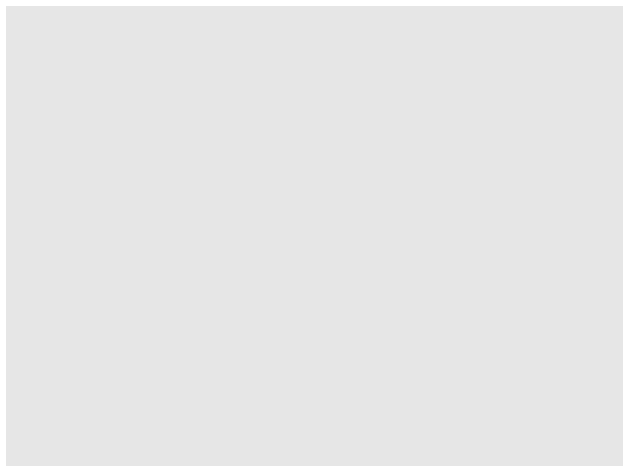

# Add geometric object with columns mapped to aesthetics

- Use the `+` operator in ggplot to add layers
- Map `age` to x-axis and `fev` to the y-axis

```
fev %>%
  ggplot(aes(x = age, y = fev)) +
  geom_point()
```

- NOTE we are implicitly saying

```
fev %>%
  ggplot(mapping = aes(x = age,
                       y = fev)) +
  geom_point()
```

**And now we have a scatterplot!**

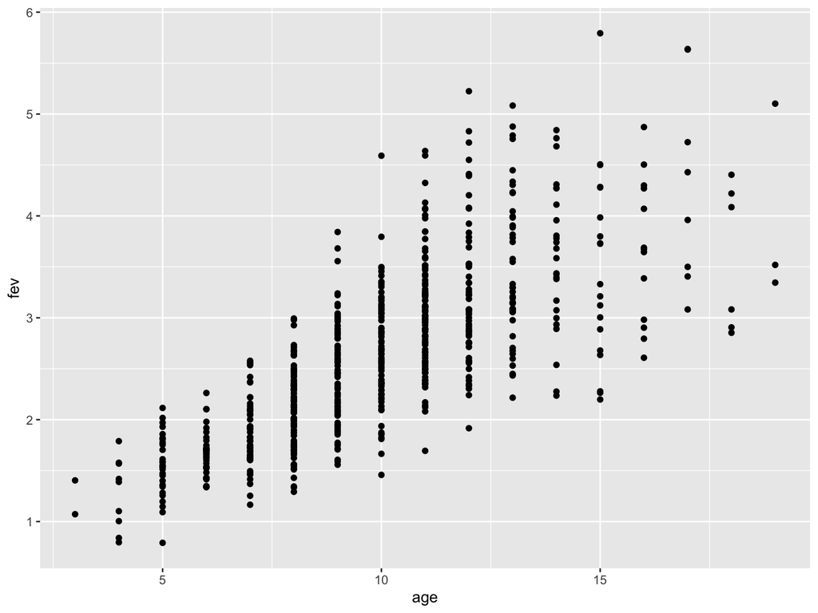

# Customise features about the layer

- Plot elements that use data *must* be wrapped in a `aes()` call

```
ggplot(fev, aes(x = age, y = fev)) +
  geom_point(aes(col = smoke))
```

**We now color the points by smoking!**

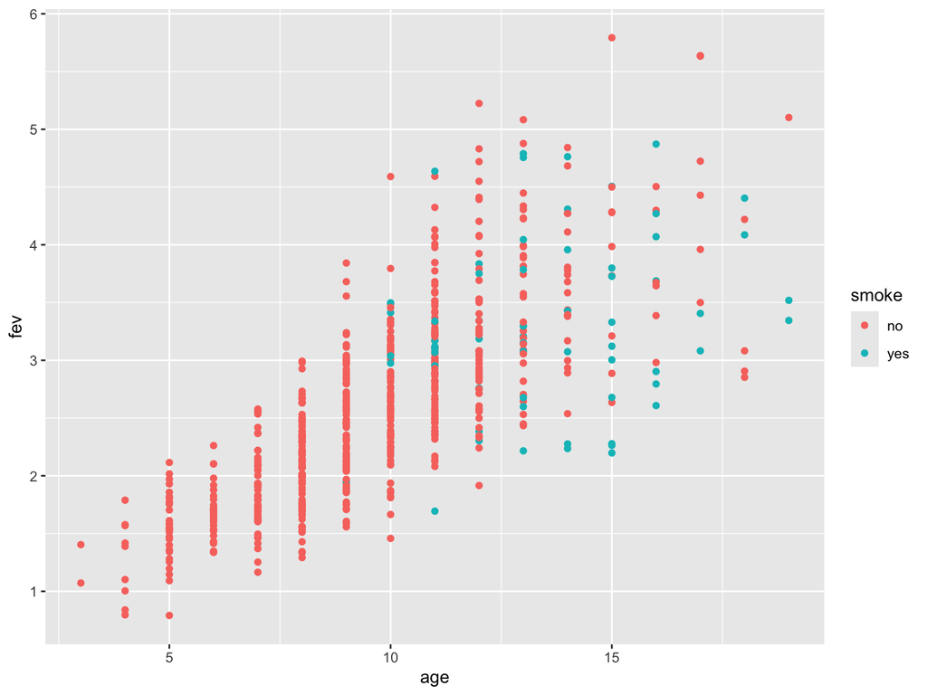

# Modifying the non-plotting elements

- Adjust global aesthetics outside of `aes()`:

```
ggplot(fev, aes(x = age, y = fev)) +
  geom_point(aes(col = smoke)) +
  # add labels
  labs(x = 'Age (years)',
       y = 'Forced Exhalation\nVol. (L/s)',
       title = 'Scatterplot') +
  # change axis
  xlim(0, 20) + ylim(0, 7)
```

**Formatting the plot**

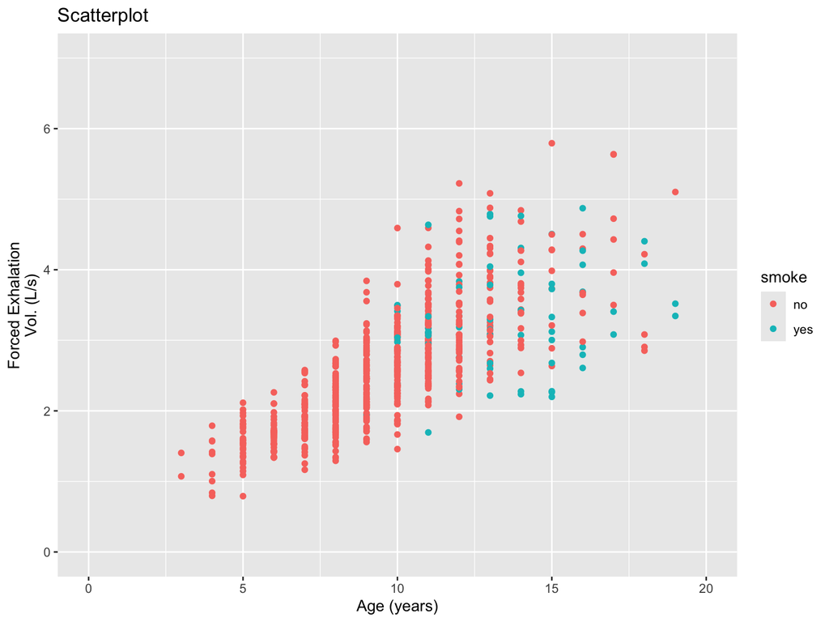

# Adjusting the aesthetics

- You can customize aesthetics that involve data!
  - Adding jitter to the points
  - Making the points slightly transparent (via `alpha`)
  - Changing the color of the points

```
ggplot(fev, aes(x = age, y = fev,
                col = smoke)) +
  geom_jitter(height = 0, width = 0.2,
              alpha = 0.5) +
  scale_color_manual(values=c("darkblue",
                              "orange")) +
  # add labels
  labs(x = 'Age (years)',
       y = 'Forced Exhalation\nVol. (L/s)',
       title = 'Scatterplot') +
  # change axis
  xlim(0, 20) + ylim(0, 7)
```

**Changing the aesthetics**

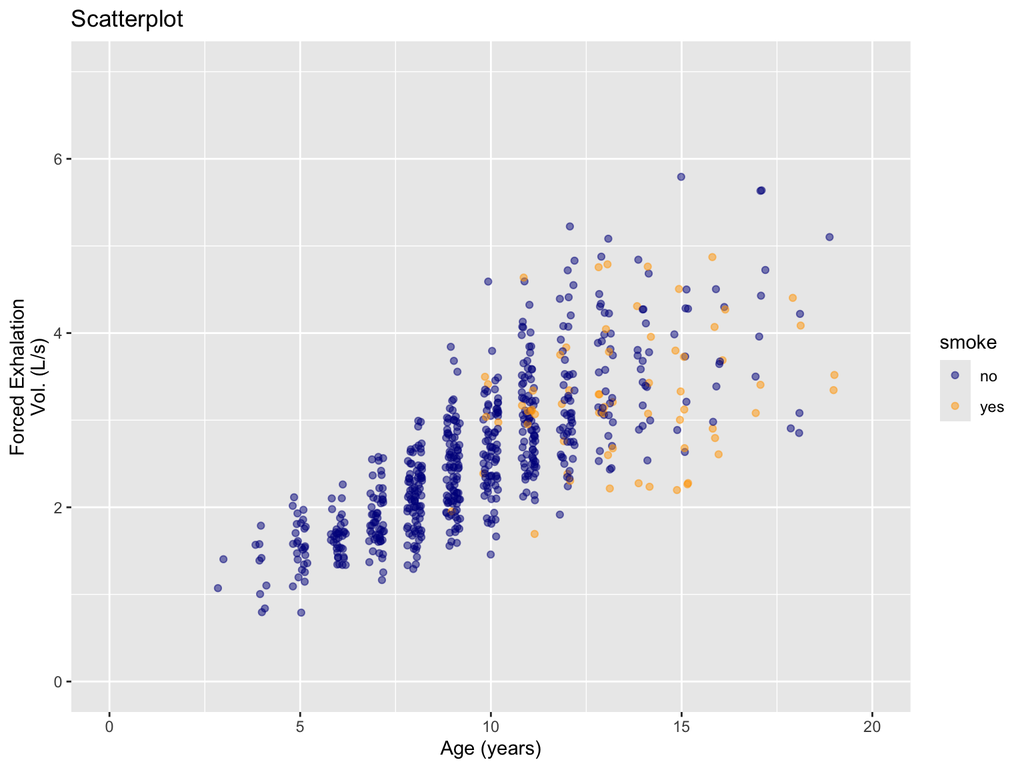

# In-class exercise (2 minutes)

What do you think is going to differ between `gg1` and `gg2`?

```r
gg1 <- ggplot(fev,
              aes(x = age, y = fev)) +
  geom_point(aes(col = smoke), alpha = 0.2) +
  geom_smooth()

gg2 <- ggplot(fev,
              aes(x = age, y = fev, col = smoke), alpha = 0.2) +
  geom_point() +
  geom_smooth()
```

# What do we think is going to differ?

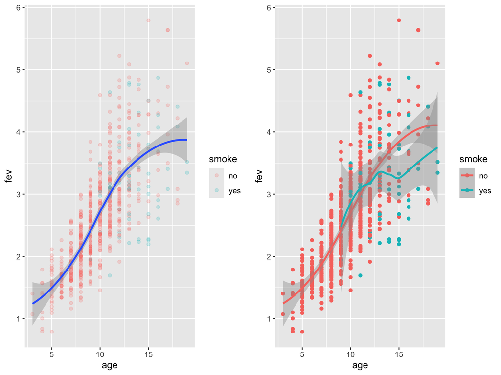

```r
ggpubr::ggarrange(gg1, gg2, common.legend=FALSE)
```

# Other types of ggplots

Of course, scatterplots are not the only type of plots!

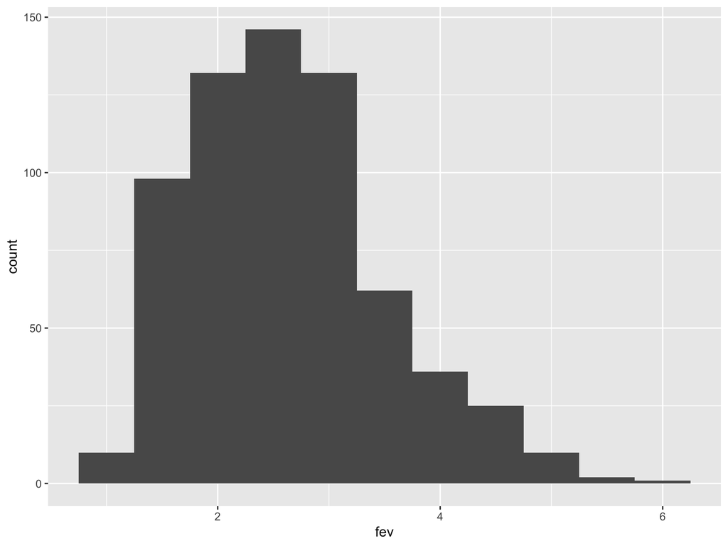

```r
ggplot(fev, aes(x = fev)) +
  geom_histogram(binwidth = 0.5)
```

# Other types of ggplots

We can have categorical variables on the x-axis…

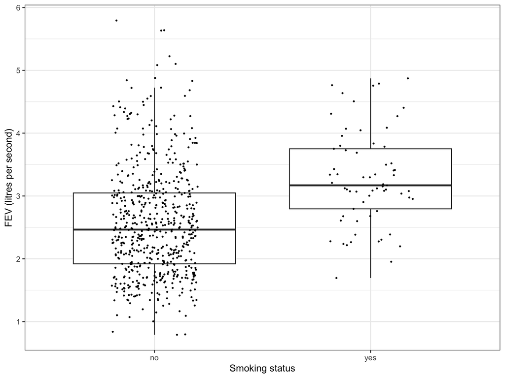

```r
fev %>%
  ggplot(aes(x = smoke, y = fev)) + theme_bw() +
  geom_boxplot(outlier.shape = NA) +
  geom_jitter(width = 0.2, height = 0, cex = 0.4) +
  xlab("Smoking status") + ylab("FEV (litres per second)")
```

# Other types of ggplots

…or on the y-axis!

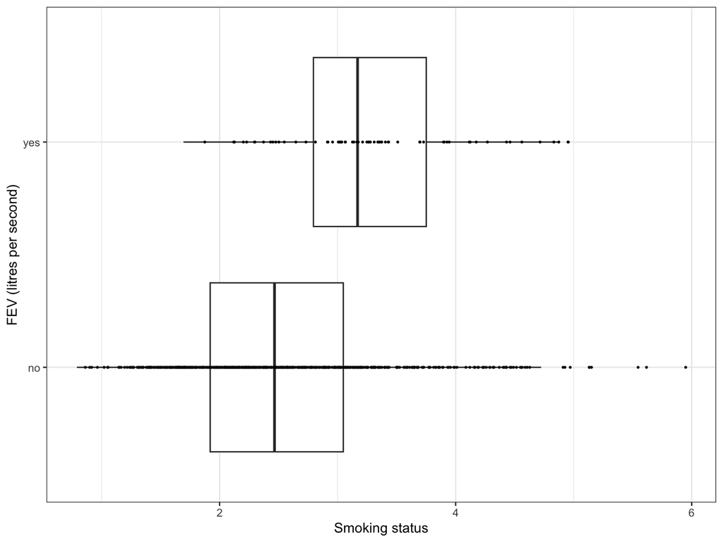

```r
fev %>%
  ggplot(aes(y = smoke, x = fev)) + theme_bw() +
  geom_boxplot(outlier.shape = NA) +
  geom_jitter(width = 0.2, height = 0, cex = 0.4) +
  xlab("Smoking status") + ylab("FEV (litres per second)")
```

# Timeseries

Line plots are good for showing trajectories, and to distinguish correlated data from uncorrelated data

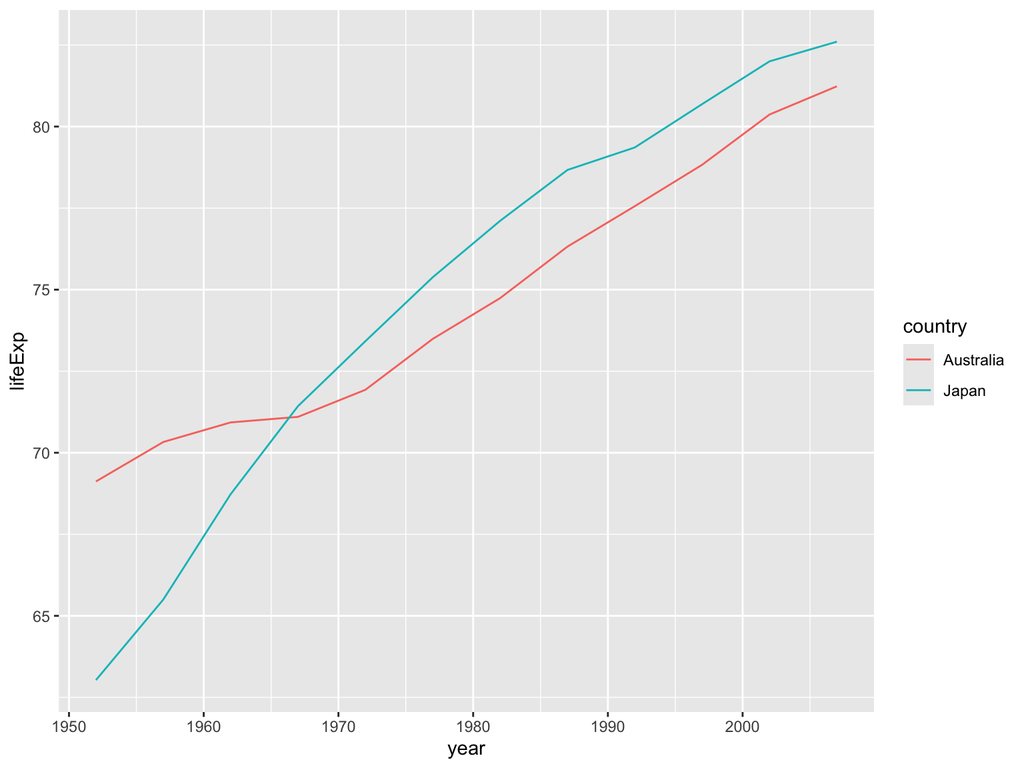

```r
library(gapminder)
g <- ggplot(gapminder %>% filter(country %in% c("Australia", "Japan")),
            aes(x = year, y = lifeExp, col = country)) + geom_line()
g
```

# Storing and modifying

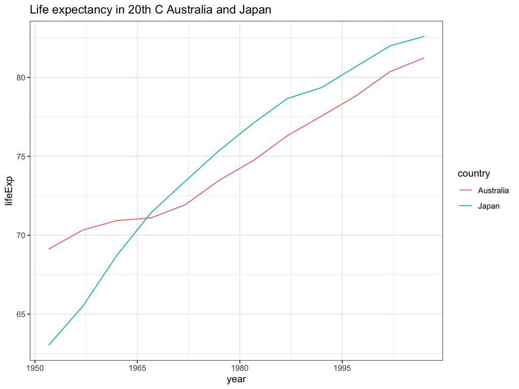

```r
g + scale_x_continuous(breaks = seq(1950, 2011, 15)) +
  theme_bw() +
  ggtitle("Life expectancy in 20th C Australia and Japan")
```

Creating and plotting `ggplot` objects is not always fast; saving them and adding to them may help

# Name to know: Edward Tufte

Highly recommended reading: *The Visual Display of Quantitative Information* by Edward Tufte

1. Show Your Data
   - Avoid premature summarization
2. Use Graphics
3. Avoid Chartjunk
4. Utilize Data-ink
5. Use Labels
6. Utilize Micro/Macro
7. Separate Layers
8. Use Multiples
9. Utilize Color
10. Understand Narrative

# Small multiples: faceting

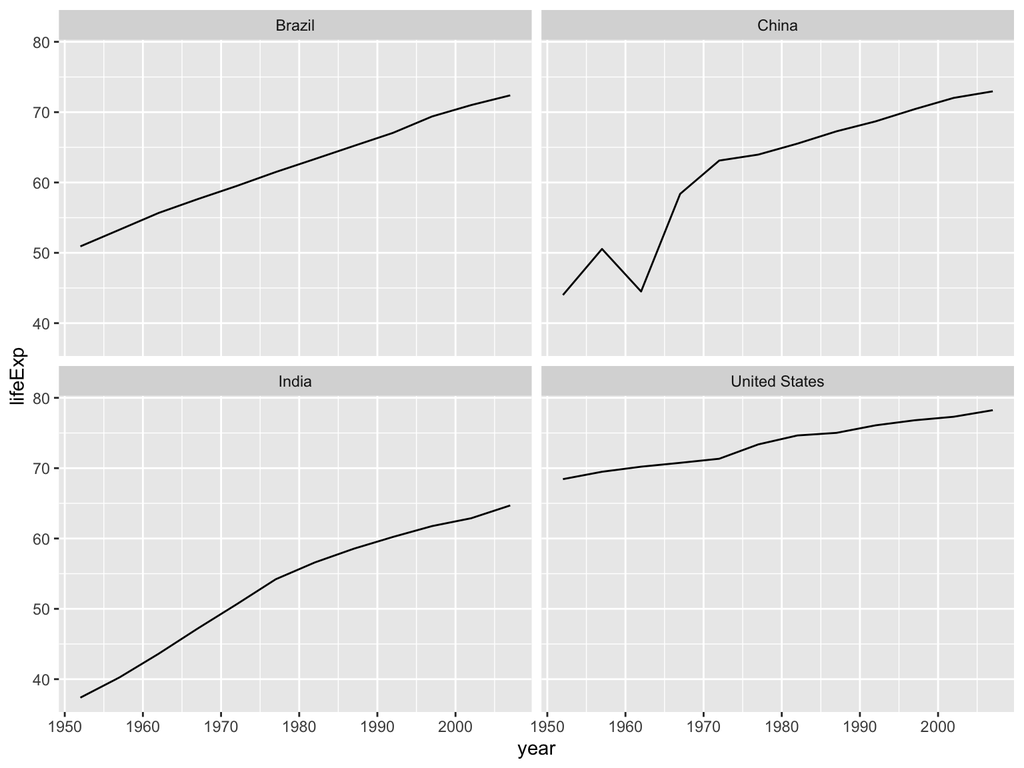

```r
gapminder %>%
  filter(country %in% c("Brazil", "China", "India", "United States")) %>%
  ggplot(aes(x = year, y = lifeExp)) + geom_line() +
  facet_wrap(~country, nrow=2)
```

# Final tips

- Align plots with similar axes
  - How do you draw the reader’s eye towards the point you want to make?
- Use figures **where appropriate**
  - Would a table suffice?
- Critique your own figures
  - Especially before public talks
- Avoid pie charts
  - Not a good use of space!

# All the layers

You can spend infinite time making your plots as detailed as beautiful and data rich as possible!

(Following example by Amy)

```r
euc_plot <- ggplot(full_data_frame[order(full_data_frame$sigma_max), ],
                   aes(x = sigma_max_char, y = mse_loss_euclidean_subset, col = Method)) +
  geom_boxplot(outlier.size=0.1) +
  xlab(label=expression(sigma[max]~": Strength of cooccurrences")) +
  ylab("Log MSE: Euclidean index") +
  theme_bw() +
  theme(text = element_text(size = 9),
        panel.border = element_blank(), panel.grid.major = element_blank(),
        panel.grid.minor = element_blank(), axis.line = element_line(colour = "black")) +
  scale_color_manual(values=c("blue", "red", "#999999", "#E69F00", "#56B4E9"))

ggpubr::ggarrange(shannon_plot, simpson_plot, bc_plot, euc_plot, ncol=2, nrow=2,
                  common.legend = T, legend="right")

ggsave("vary_sigma_max_beta_sd_1_n_20_p_2_q_20_sigma_min_0_01_all_shared.png", width=6, height = 4)
```

# All the layers

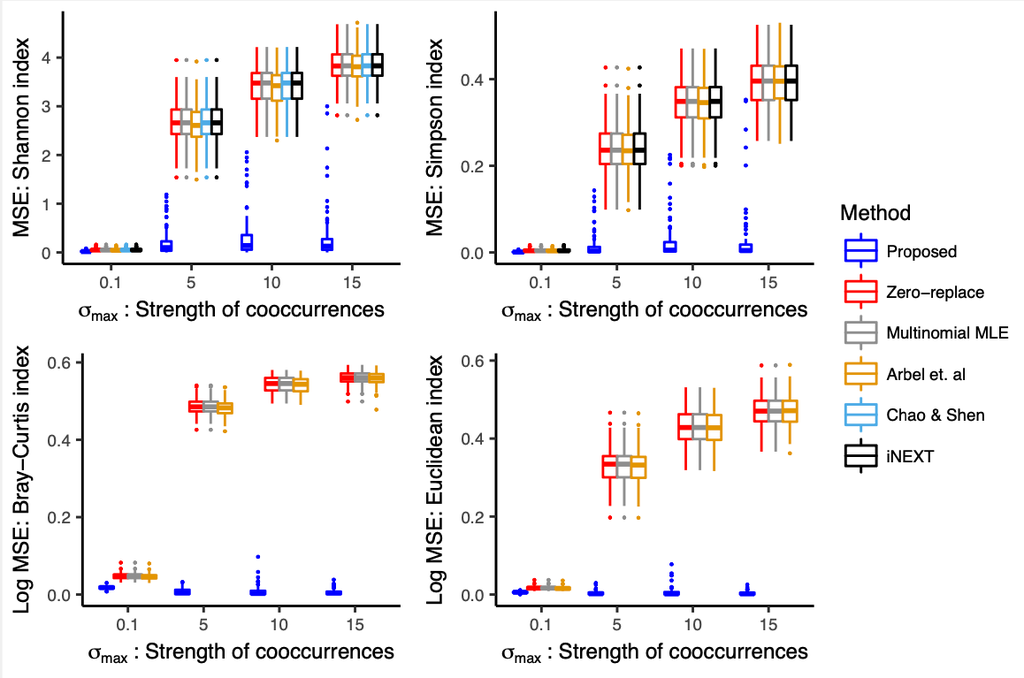

# Additional resources

- For Tidyverse
  - https://www.rstudio.com/wp-content/uploads/2015/02/data-wrangling-cheatsheet.pdf
  - https://raw.githubusercontent.com/rstudio/cheatsheets/main/tidyr.pdf
- For ggplot
  - https://github.com/rstudio/cheatsheets/blob/main/data-visualization.pdf
  - https://r-graph-gallery.com/
  - https://r4ds.had.co.nz/data-visualisation.html

# With the remaining time…

- Going over the premise of Homework 2
- Next week:
  - A bit more details about Homework 2 (“long” vs “wide” format, `igraph`)
  - How R packages work
  - Guiding principles of designing functions

# Acknowledgments

- Amy Willis
- Ron Yurko: https://github.com/ryurko/DataViz-36613-Fall23